# Statistical Modeling

#### Addressing Confounding Variables

It looks like lower quality diamonds have higher prices because there is an important confounding variable: the weight (carat) of the diamond. The weight of the diamond is the single most important factor for determining the price of the diamond, and lower quality diamonds tend to be larger.

1. Focus on diamonds smaller than 2.5 carats (99.7% of the data)
2. Log-transform the carat and price variables.

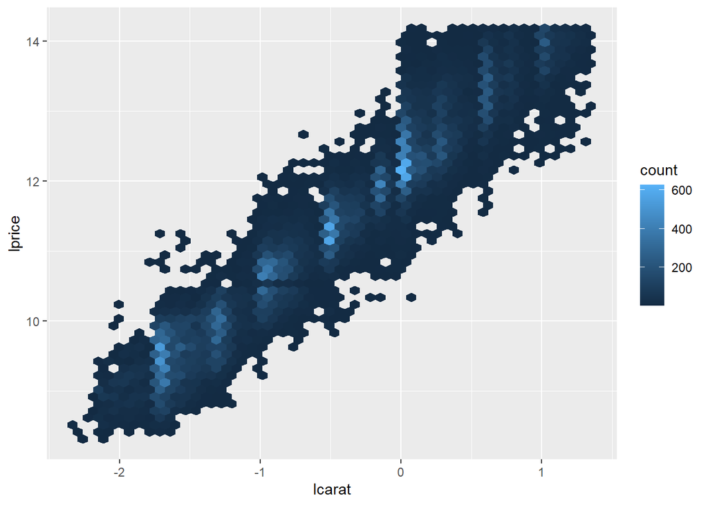

```r
library(hexbin)
diamonds2 <- diamonds %>%
  filter(carat <= 2.5) %>%
  mutate(lprice = log2(price), lcarat = log2(carat))

ggplot(diamonds2, aes(lcarat, lprice)) + geom_hex(bins = 50)
```

```r
mod_diamond <- lm(lprice ~ lcarat, data = diamonds2)
broom::tidy(mod_diamond)
```

```
# A tibble: 2 × 5
  term        estimate std.error statistic p.value
  <chr>          <dbl>     <dbl>     <dbl>   <dbl>
1 (Intercept)    12.2    0.00197     6194.       0
2 lcarat          1.68   0.00194      868.       0
```

#### Incorporating Categorical Variables

A more complex model includes additional predictors like color, cut, and clarity, providing a comprehensive understanding of their effects.

```r
mod_diamond2 <- lm(lprice ~ lcarat + color + cut + clarity, data = diamonds2)
broom::tidy(mod_diamond2)
```

```
# A tibble: 19 × 5
   term        estimate std.error statistic   p.value
   <chr>          <dbl>     <dbl>     <dbl>     <dbl>
 1 (Intercept) 12.2       0.00169  7212.    0
 2 lcarat       1.89      0.00112  1678.    0
 3 color.L     -0.634     0.00291  -218.    0
 4 color.Q     -0.138     0.00268   -51.4   0
 5 color.C     -0.0221    0.00250    -8.82  1.19e- 18
 6 color^4      0.0166    0.00230     7.21  5.54e- 13
 7 color^5     -0.00283   0.00217    -1.30  1.92e-  1
 8 color^6      0.00353   0.00197     1.79  7.30e-  2
 9 cut.L        0.174     0.00339    51.3   0
10 cut.Q       -0.0503    0.00298   -16.9   6.89e- 64
11 cut.C        0.0191    0.00258     7.41  1.31e- 13
12 cut^4       -0.00241   0.00207    -1.17  2.43e-  1
13 clarity.L    1.31      0.00518   253.    0
14 clarity.Q   -0.334     0.00484   -69.0   0
15 clarity.C    0.178     0.00414    43.1   0
16 clarity^4   -0.0881    0.00330   -26.7   5.33e-156
17 clarity^5    0.0359    0.00268    13.4   8.12e- 41
18 clarity^6   -0.00137   0.00233    -0.589 5.56e-  1
19 clarity^7    0.0482    0.00205    23.5   1.28e-121
```

#### Broom

Used to tidy up modeling output. https://broom.tidymodels.org/

- tidy
- augment
- glance

## Many Models

### Fundamentals

1. **Using Many Simple Models**: Employing a multitude of simple models aids in comprehending intricate datasets.
2. **List-Columns**: Leveraging list-columns to store diverse data structures within a data frame, such as a column containing linear models.
3. **Broom Package**: Utilizing the broom package by David Robinson to convert models into tidy data, enabling the application of various analysis techniques.

### gapminder

The [gapminder](https://cran.r-project.org/web/packages/gapminder/readme/README.html) data summarises the progression of countries over time, looking at statistics like life expectancy and GDP. Let’s focus addressing: “How does life expectancy change over time for each country?” Initial plots are hard to interpret due to the dataset’s size. To address this, linear models are fitted to each country to identify trends.

#### ModelR

Piping within the tidyverse and modeling https://modelr.tidyverse.org/

```r
library(modelr)
library(gapminder)
gapminder
```

```
# A tibble: 1,704 × 6
   country     continent  year lifeExp      pop gdpPercap
   <fct>       <fct>     <int>   <dbl>    <int>     <dbl>
 1 Afghanistan Asia       1952    28.8  8425333      779.
 2 Afghanistan Asia       1957    30.3  9240934      821.
 3 Afghanistan Asia       1962    32.0 10267083      853.
 4 Afghanistan Asia       1967    34.0 11537966      836.
 5 Afghanistan Asia       1972    36.1 13079460      740.
 6 Afghanistan Asia       1977    38.4 14880372      786.
 7 Afghanistan Asia       1982    39.9 12881816      978.
 8 Afghanistan Asia       1987    40.8 13867957      852.
 9 Afghanistan Asia       1992    41.7 16317921      649.
10 Afghanistan Asia       1997    41.8 22227415      635.
# ℹ 1,694 more rows
```

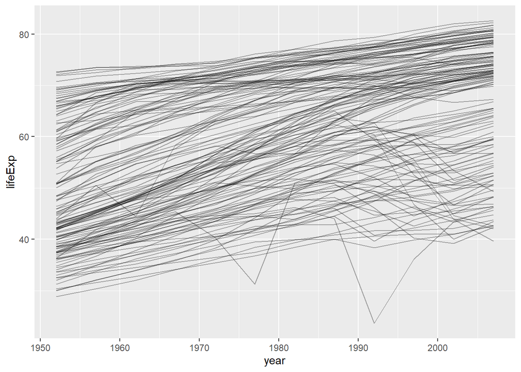

```r
gapminder %>%
  ggplot(aes(year, lifeExp, group = country)) +
    geom_line(alpha = 1/3)
```

```r
# Example with New Zealand
nz <- filter(gapminder, country == "New Zealand")
nz_mod <- lm(lifeExp ~ year, data = nz)
## can't look at all countries
```

### Nested data

To fit models to every country efficiently, we use nested data frames, which group data by country and continent.

```r
by_country <- gapminder %>%
  group_by(country, continent) %>%
  nest()
by_country
```

```
# A tibble: 142 × 3
# Groups:   country, continent [142]
   country     continent data
   <fct>       <fct>     <list>
 1 Afghanistan Asia      <tibble [12 × 4]>
 2 Albania     Europe    <tibble [12 × 4]>
 3 Algeria     Africa    <tibble [12 × 4]>
 4 Angola      Africa    <tibble [12 × 4]>
 5 Argentina   Americas  <tibble [12 × 4]>
 6 Australia   Oceania   <tibble [12 × 4]>
 7 Austria     Europe    <tibble [12 × 4]>
 8 Bahrain     Asia      <tibble [12 × 4]>
 9 Bangladesh  Asia      <tibble [12 × 4]>
10 Belgium     Europe    <tibble [12 × 4]>
# ℹ 132 more rows
```

### List-Columns

A model-fitting function is defined, and the map function is used to apply it to each country’s data. The resulting models are stored as list-columns in the data frame.

```r
country_model <- function(df) {
  lm(lifeExp ~ year, data = df)
}

by_country <- by_country %>%
  mutate(model = map(data, country_model))
```

### Unnesting

Residuals are computed for each model-data pair, and the nested data frame is transformed into a regular data frame using unnest.

```r
by_country <- by_country %>%
  mutate(
    resids = map2(data, model, add_residuals)
  )
by_country
```

```
# A tibble: 142 × 5
# Groups:   country, continent [142]
   country     continent data              model  resids
   <fct>       <fct>     <list>            <list> <list>
 1 Afghanistan Asia      <tibble [12 × 4]> <lm>   <tibble [12 × 5]>
 2 Albania     Europe    <tibble [12 × 4]> <lm>   <tibble [12 × 5]>
 3 Algeria     Africa    <tibble [12 × 4]> <lm>   <tibble [12 × 5]>
 4 Angola      Africa    <tibble [12 × 4]> <lm>   <tibble [12 × 5]>
 5 Argentina   Americas  <tibble [12 × 4]> <lm>   <tibble [12 × 5]>
 6 Australia   Oceania   <tibble [12 × 4]> <lm>   <tibble [12 × 5]>
 7 Austria     Europe    <tibble [12 × 4]> <lm>   <tibble [12 × 5]>
 8 Bahrain     Asia      <tibble [12 × 4]> <lm>   <tibble [12 × 5]>
 9 Bangladesh  Asia      <tibble [12 × 4]> <lm>   <tibble [12 × 5]>
10 Belgium     Europe    <tibble [12 × 4]> <lm>   <tibble [12 × 5]>
# ℹ 132 more rows
```

```r
resids <- unnest(by_country, resids)
resids
```

```
# A tibble: 1,704 × 9
# Groups:   country, continent [142]
   country     continent data     model   year lifeExp     pop gdpPercap   resid
   <fct>       <fct>     <list>   <list> <int>   <dbl>   <int>     <dbl>   <dbl>
 1 Afghanistan Asia      <tibble> <lm>    1952    28.8  8.43e6      779. -1.11
 2 Afghanistan Asia      <tibble> <lm>    1957    30.3  9.24e6      821. -0.952
 3 Afghanistan Asia      <tibble> <lm>    1962    32.0  1.03e7      853. -0.664
 4 Afghanistan Asia      <tibble> <lm>    1967    34.0  1.15e7      836. -0.0172
 5 Afghanistan Asia      <tibble> <lm>    1972    36.1  1.31e7      740.  0.674
 6 Afghanistan Asia      <tibble> <lm>    1977    38.4  1.49e7      786.  1.65
 7 Afghanistan Asia      <tibble> <lm>    1982    39.9  1.29e7      978.  1.69
 8 Afghanistan Asia      <tibble> <lm>    1987    40.8  1.39e7      852.  1.28
 9 Afghanistan Asia      <tibble> <lm>    1992    41.7  1.63e7      649.  0.754
10 Afghanistan Asia      <tibble> <lm>    1997    41.8  2.22e7      635. -0.534
# ℹ 1,694 more rows
```

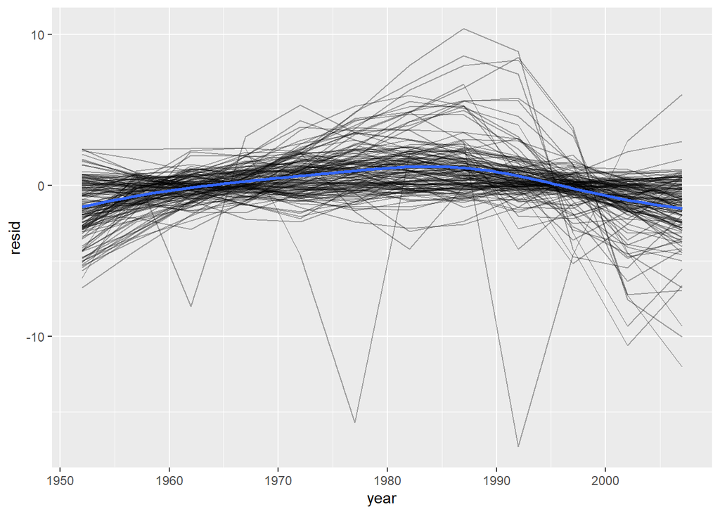

```r
resids %>%
  ggplot(aes(year, resid)) +
    geom_line(aes(group = country), alpha = 1 / 3) +
    geom_smooth(se = FALSE)
```

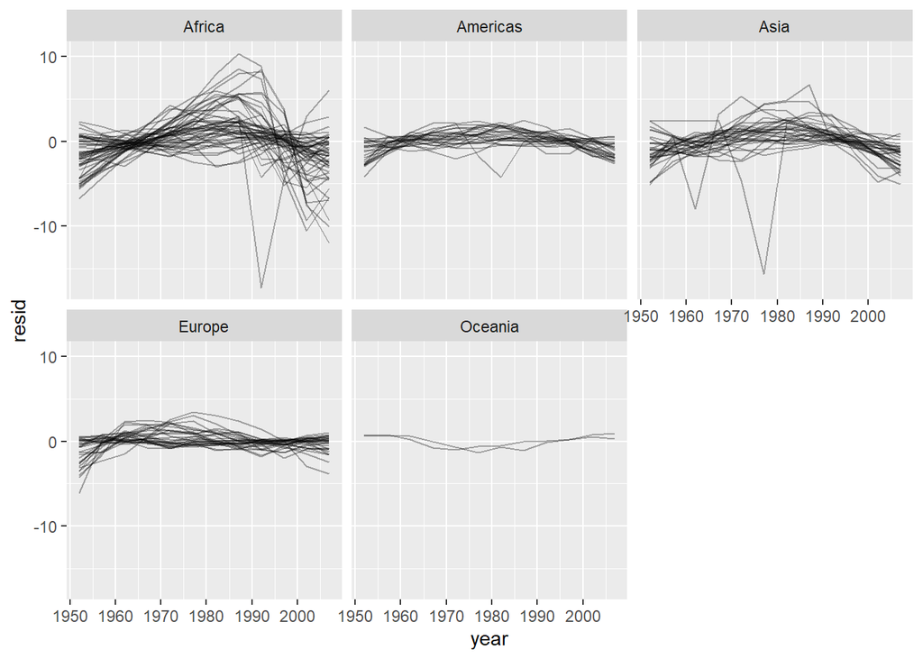

```r
## by continent
resids %>%
  ggplot(aes(year, resid, group = country)) +
    geom_line(alpha = 1 / 3) +
    facet_wrap(~continent)
```

### Model Quality

The broom package is introduced for assessing model quality. The glance function is applied to extract model quality metrics, providing insights into model performance.

```r
glance <- by_country %>%
  mutate(glance = map(model, broom::glance)) %>%
  unnest(glance, .drop = TRUE)
glance
```

```
# A tibble: 142 × 17
# Groups:   country, continent [142]
   country     continent data     model  resids   r.squared adj.r.squared sigma
   <fct>       <fct>     <list>   <list> <list>       <dbl>         <dbl> <dbl>
 1 Afghanistan Asia      <tibble> <lm>   <tibble>     0.948         0.942 1.22
 2 Albania     Europe    <tibble> <lm>   <tibble>     0.911         0.902 1.98
 3 Algeria     Africa    <tibble> <lm>   <tibble>     0.985         0.984 1.32
 4 Angola      Africa    <tibble> <lm>   <tibble>     0.888         0.877 1.41
 5 Argentina   Americas  <tibble> <lm>   <tibble>     0.996         0.995 0.292
 6 Australia   Oceania   <tibble> <lm>   <tibble>     0.980         0.978 0.621
 7 Austria     Europe    <tibble> <lm>   <tibble>     0.992         0.991 0.407
 8 Bahrain     Asia      <tibble> <lm>   <tibble>     0.967         0.963 1.64
 9 Bangladesh  Asia      <tibble> <lm>   <tibble>     0.989         0.988 0.977
10 Belgium     Europe    <tibble> <lm>   <tibble>     0.995         0.994 0.293
# ℹ 132 more rows
# ℹ 9 more variables: statistic <dbl>, p.value <dbl>, df <dbl>, logLik <dbl>,
#   AIC <dbl>, BIC <dbl>, deviance <dbl>, df.residual <int>, nobs <int>
```

```r
glance %>%
  arrange(r.squared)
```

```
# A tibble: 142 × 17
# Groups:   country, continent [142]
   country       continent data     model resids   r.squared adj.r.squared sigma
   <fct>         <fct>     <list>   <lis> <list>       <dbl>         <dbl> <dbl>
 1 Rwanda        Africa    <tibble> <lm>  <tibble>    0.0172      -0.0811   6.56
 2 Botswana      Africa    <tibble> <lm>  <tibble>    0.0340      -0.0626   6.11
 3 Zimbabwe      Africa    <tibble> <lm>  <tibble>    0.0562      -0.0381   7.21
 4 Zambia        Africa    <tibble> <lm>  <tibble>    0.0598      -0.0342   4.53
 5 Swaziland     Africa    <tibble> <lm>  <tibble>    0.0682      -0.0250   6.64
 6 Lesotho       Africa    <tibble> <lm>  <tibble>    0.0849      -0.00666  5.93
 7 Cote d'Ivoire Africa    <tibble> <lm>  <tibble>    0.283        0.212    3.93
 8 South Africa  Africa    <tibble> <lm>  <tibble>    0.312        0.244    4.74
 9 Uganda        Africa    <tibble> <lm>  <tibble>    0.342        0.276    3.19
10 Congo, Dem. … Africa    <tibble> <lm>  <tibble>    0.348        0.283    2.43
# ℹ 132 more rows
# ℹ 9 more variables: statistic <dbl>, p.value <dbl>, df <dbl>, logLik <dbl>,
#   AIC <dbl>, BIC <dbl>, deviance <dbl>, df.residual <int>, nobs <int>
```

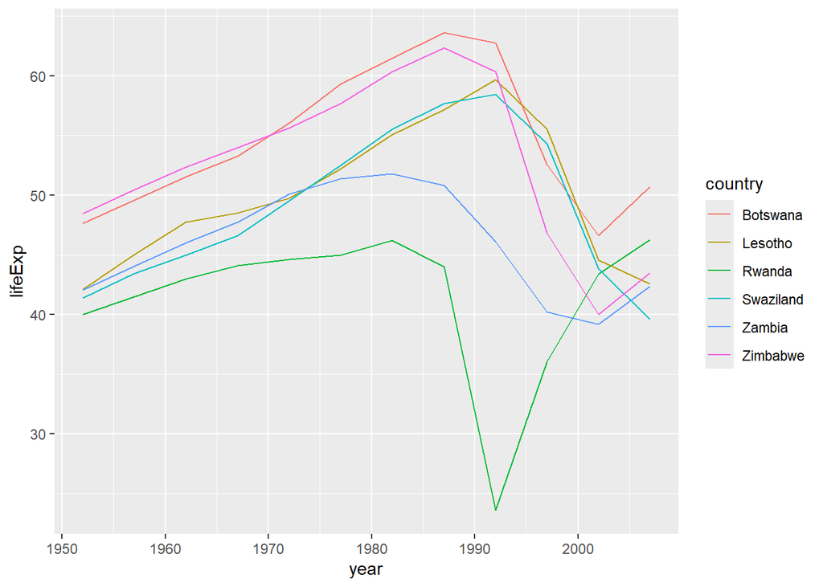

```r
bad_fit <- filter(glance, r.squared < 0.25)

gapminder %>%
  semi_join(bad_fit, by = "country") %>%
  ggplot(aes(year, lifeExp, colour = country)) +
    geom_line()
```

On your Own…

1. Diamonds - use color cut and clarity to model price. (log transform if needed and analyze residuals and diagnostics).
2. Gapminder - predict life expantancy by continent (analyze fully)